# Identification of key risk factors associated with severe hypoglycemia in older adults with Type 1 Diabetes

Nikki L. B. Freeman

This notebook contains the main steps in the analysis for “Identification of key risk factors associated with severe hypoglycemia in older adults with Type 1 Diabetes”. Function files are located in the same directory as this notebook.

# Packages, functions, and data

The `getRawDataTables` function reads in the individual data tables from the raw data set.

```r
# Packages needed for the analysis
library(tidyverse)
library(mice)
library(caret)
library(randomForest)
library(glmnet)
library(xtable)
library(table1)

# Functions
source("1_createAnalysisRaw.R")
source("2_dataPreparation2.R")
source("3_imputation.R")
source("4_randomForest.R")
source("5_regLogisticReg.R")

# Load the raw data
dataTables <- getRawDataTables("../")
```

# Data cleaning and preparation

The `collectVariables` function extracts from each data table, the variables of interest for the analysis. For some variables, minor data cleaning is completed, including

- Adding an inclusion/exclusion variable: two participants are excluded due to not having any demographic data available
- Adjudicating duplicate lab results: if one entry is NULL and the other is not, take the non-NULL entry; otherwise, average the entries.
- Scoring the diabetes numeracy test
- Scoring the geriatric depression test
- Identifying beta blockers from the medication list and creating a binary beta blocker variable
- Scoring the hypoglycemia unawareness survey

```r
# Collect the variables of interest from the various tables and put into a single analysisData_raw dataframe
# Some variables are missing their scores or are re-coded
analysisData_raw <- collectVariables(dataTables)
# Write the analysis data to a csv
write_csv(x = analysisData_raw, file = "../2_pipeline/1_analysis_raw.csv")

# Create analytic data set for analysis
analysisWithMissing <- makeAnalysisDataWithMissing(analysisData_raw = analysisData_raw)
 # Write the analysis data set to a csv
write_csv(x = analysisWithMissing, file = "../2_pipeline/2_analysisDataWithMissing.csv")
```

# Imputation and preparation of testing and training sets

The `getImputationDataSets` function takes the observed data for analysis and creates 5 imputed dated sets. The full observed data set for imputation. The `createTrainTest` function takes the imputed dated and observed data to generate a test set composed of only complete cases and 5 imputation sets that are used for training the models (effectively, these are folds).

```r
set.seed(5678)
imputedData <- getImputationDataSets(analysisWithMissing = analysisWithMissing)
trainTest <- createTrainTest(analysisWithMissing = analysisWithMissing, imputedData = imputedData)
```

# Random forest

## Model fitting

This code chunk fits a RF to the training sets, generates predictions for the testing set, and extracts the variable importance for the trained models.

```r
rfObjs <- map(trainTest$trainingSets_list, rfHelper)

rfPredictions <- map(rfObjs, predict, newdata = trainTest$testingData %>%
                       dplyr::select(-c(BCaseControlStatus, PtID)))

rfImportance <- map(rfObjs, rfImportanceHelper)
```

## Model assessment

This chunk grabs the prediction metrics for the RF model and creates a dataframe of the prediction metrics that will be used for the prediction performance plot.

```r
rf_metrics <- map(rfPredictions, confusionMatrix, reference = factor(trainTest$testingData$BCaseControlStatus))

rf_plotMetrics <- data.frame(reduce(map(1:5, ~rf_metrics[[.]]$byClass), rbind)) %>%
  mutate(Method = "RF")
```

# L1-Regularized logistic regression

## Model fitting

This code chunk fits a LR model to the training sets, generates predictions for the testing set, and extracts the variable importance for the trained models.

```r
regLogisticRegObj <- map(trainTest$trainingSets_list, regLogisticReg_helper)

regLogisticRegPredictions <- map(regLogisticRegObj, predict, convertTestCategoricalToBinary(trainTest$testingData))

regLogisticRegImportance <- map(regLogisticRegObj, varImp)
```

## Model assessment

This chunk grabs the prediction metrics for the LR model and creates a dataframe of the prediction metrics that will be used for the prediction performance plot.

```r
regLog_metrics <- map(regLogisticRegPredictions, confusionMatrix, reference = factor(trainTest$testingData$BCaseControlStatus))
regLog_plotMetrics <- data.frame(reduce(map(1:5, ~regLog_metrics[[.]]$byClass), rbind)) %>%
  mutate(Method = "LR")
```

# SVM

## Model fitting

This code chunk fits a SVM model to the training sets and generates predictions for the testing set.

```r
svmHelper <- function(trainingSet){
  temp <- convertTrainingCategoricalToBinary(trainingSet)
  e1071::svm(x = temp, y = as.factor(trainingSet$BCaseControlStatus))
}

svmObjs <- map(trainTest$trainingSets_list, svmHelper)
svmPredictions <- map(svmObjs, predict, convertTestCategoricalToBinary_svm(trainTest$testingData))
```

## Model assessment

```r
svm_metrics <- map(svmPredictions, confusionMatrix, reference = factor(trainTest$testingData$BCaseControlStatus))
svm_plotMetrics <- data.frame(reduce(map(1:5, ~svm_metrics[[.]]$byClass), rbind)) %>%
  mutate(Method = "SVM")
```

# Prediction performance plots

This chunk generates the predictive performance plots.

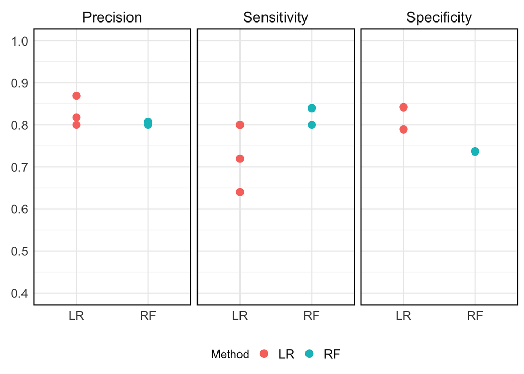

```r
predPerfDF <- bind_rows(rf_plotMetrics, regLog_plotMetrics) %>%
  # bind_rows(rf_plotMetrics, regLog_plotMetrics, svm_plotMetrics) %>%
  mutate(fold = rep(1:5, 2)) %>%
  dplyr::select(Method, fold, Sensitivity, Specificity, Precision) %>%
  pivot_longer(cols = c(Sensitivity, Specificity, Precision),
               names_to = "metric", values_to = "value") %>%
  replace_na(list(value = 0))

predPerfPlot <- predPerfDF %>%
  ggplot(aes(x = Method, y = value, color = Method)) +
  geom_point(size = 3) +
  facet_wrap(~metric) +
  theme_minimal() +
  labs(y = element_blank(), x = element_blank()) +
  scale_y_continuous(breaks = seq(0.4, 1.0, by = 0.1), labels = c(as.character(seq(0.4, 0.9, by = 0.1)), "1.0"),
                     limits = c(0.4, 1.0)) +
  theme(legend.position = "bottom",
        panel.border = element_rect(color = "black", linewidth = 1, fill = NA),
        strip.text = element_text(size = 14),
        axis.text = element_text(size = 12),
        legend.text = element_text(size = 12))

predPerfPlot
```

```r
ggsave(predPerfPlot, file = "../3_output/0_predPerfPlot.png", device = "png",
       bg = "white", width = 12, height = 6, units = "in")
```

# Average predictive performance

```r
# Average of the predictive performance measures across folds
predPerfDF %>%
  group_by(Method, metric) %>%
  summarise(mean = round(mean(value), 2),
            sd = round(sd(value), 2)) %>%
  arrange(metric)
```

| Method | metric | mean | sd |
| --- | --- | --- | --- |
| LR | Precision | 0.85 | 0.03 |
| RF | Precision | 0.81 | 0.00 |
| LR | Sensitivity | 0.75 | 0.07 |
| RF | Sensitivity | 0.83 | 0.02 |
| LR | Specificity | 0.82 | 0.03 |
| RF | Specificity | 0.74 | 0.00 |

```r
# Average accuracy, etc across folds
round(colMeans(reduce(map(rf_metrics, ~pluck(., "overall")), rbind)), 2)
```

```
##       Accuracy          Kappa  AccuracyLower  AccuracyUpper   AccuracyNull
##           0.79           0.57           0.64           0.90           0.57
## AccuracyPValue  McnemarPValue
##           0.00           1.00
```

```r
round(colMeans(reduce(map(regLog_metrics, ~pluck(., "overall")), rbind)), 2)
```

```
##       Accuracy          Kappa  AccuracyLower  AccuracyUpper   AccuracyNull
##           0.78           0.56           0.63           0.89           0.57
## AccuracyPValue  McnemarPValue
##           0.01           0.60
```

```r
round(colMeans(reduce(map(svm_metrics, ~pluck(., "overall")), rbind)), 2)
```

```
##       Accuracy          Kappa  AccuracyLower  AccuracyUpper   AccuracyNull
##           0.43           0.00           0.28           0.59           0.57
## AccuracyPValue  McnemarPValue
##           0.98           0.00
```

# Variable importance

```r
data.frame(reduce(map2(1:5,rfImportance, function(x, y) y %>% mutate(fold = x)), rbind)) %>%
  arrange(fold, desc(MeanDecreaseGini)) %>%
  group_by(fold) %>%
  slice_max(MeanDecreaseGini, n = 5)
```

| predictor | MeanDecreaseGini | fold |
| --- | --- | --- |
| hypoUnaware | 8.918151 | 1 |
| pctCV_day | 3.780087 | 1 |
| bgLess70_pct_day | 3.101906 | 1 |
| SymbDigWTotCorr | 2.882929 | 1 |
| TrailMakATotTime | 2.866567 | 1 |
| hypoUnaware | 8.547904 | 2 |
| pctCV_day | 3.403708 | 2 |
| SymbDigWTotCorr | 3.086427 | 2 |
| bgLess70_pct_day | 2.929777 | 2 |
| TrailMakATotTime | 2.890274 | 2 |

[output cut: 15 more lines]

```r
regLogisticRegImportance
```

```
## [[1]]
## glmnet variable importance
##
##   only 20 most important variables shown (out of 60)
##
##                          Overall
## hypo_unaware           100.00000
## hypo_reducedAwareness   85.33931
## glucoseMonitoring_1to3  41.24780
## abnormalCreatinine      36.03334
## betaBlocker             26.32467
## bingeAlc                12.20606
## nonHispWhite             9.41290
## geriDepressionScore      1.78967
## bgLess70_pct_day         1.18193
## annualInc_less35k        0.78125
## pctCV_day                0.40684
## SymbDigWTotCorr          0.11945
## GrPegDomTotTime          0.03128
## TrailMakBTotTime         0.03098
## detectableCPEP           0.00000
## annualInc_35to50k        0.00000
## SymbDigOTotCorr          0.00000
## DaysWkEx                 0.00000
## Gender                   0.00000
## insDose_40to60           0.00000
##
## [[2]]
## glmnet variable importance
##
##   only 20 most important variables shown (out of 60)
##
##                           Overall
## hypo_unaware             100.0000
## hypo_reducedAwareness     68.8741
## glucoseMonitoring_1to3    45.7682
## abnormalCreatinine        36.1913
## bingeAlc                  33.8375
## betaBlocker               31.3232
## nonHispWhite              22.3284
```

[output cut: 79 more lines]

```
## betaBlocker               35.460
## LiveAlone                 21.185
## annualInc_less35k         19.910
## insDose_greater60         14.649
## frailty                   11.731
## college                   10.990
## geriDepressionScore       10.162
## hospWithDKA               10.073
## insurance_none             9.632
## annualInc_35to50k          9.039
## glucoseMonitoring_10plus   8.906
## InsDeliveryMethod          7.097
## overweight                 6.168
## insDose_40to60             5.781
## bingeAlc                   5.272
```

# Descriptives table

```r
table1df <- analysisWithMissing %>%
  filter(str_detect(exclude, "No")) %>%
  mutate(Gender = factor(Gender, levels = c("F", "M"), labels = c("Female", "Male")),
         `Non-Hispanic White` = factor(nonHispWhite, levels = c(1, 0), labels = c("Yes", "No")),
         `Exercise (days per week)` = DaysWkEx,
         `Lives alone` = LiveAlone,
         `Insulin delivery method` = InsDeliveryMethod,
         `Units Insulin (bolus or long acting)` = UnitsInsBasalOrLongAct,
         `Number boluses or injections short acting per day` = NumPumpBolusOrShortAct,
         `Hospitalized DKA in last year` = factor(hospWithDKA, levels = c(0, 1),
                                                  labels = c("No", "Yes")),
         HBA1C = as.numeric(HBA1C),
         `Glucose` = GLU,
         `CGM %Glucose <70 (day)` = bgLess70_pct_day,
         `CGM %Glucose <70 (night)` = bgLess70_pct_night,
         `CGM %Glucose >180 (day)` = bgGreater180_pct_day,
         `CGM %Glucose >180 (night)` = bgGreater180_pct_night,
         `Mean Glucose (day)` = meanGlucose_day,
         `Mean Glucose (night)` = meanGlucose_night,
         `%CV (day)` = pctCV_day,
         `%CV (night)` = pctCV_night,
         `Beta blocker use` = factor(betaBlocker, levels = c(1, 0), labels = c("Yes", "no")),
         `Symbolic Digits Written test` = SymbDigWTotCorr,
         `Symbolic Digits Oral test` = SymbDigOTotCorr,
         `Hopkins Verbal Learning test - Total` = hopkinsTotal,
         `Hopkins Verbal Learning test - Recall` = hopkinsRecall,
         `Trail Making test A` = TrailMakATotTime,
         `Trail Making test B` = TrailMakBTotTime,
         `Grooved Peg Board test (dominant hand)` = GrPegDomTotTime,
         `Functional Activity score` = FuncActTotTestScore,
         `Duke Social Support scale` = DukeSocTotDSSI,
         `Geriatric Depression score` = geriDepressionScore,
         `Hyperglycemia fear score` = hyperFear,
         `Hypoglycemia unawareness` = factor(hypoUnaware, levels = c("hypo aware", "reduced awareness", "unaware"),
                                             labels = c("Aware", "Reduced awareness", "Unaware")),
         `Diabetes Numeracy score` = diabNumeracyScore,
         `Montreal Cognitive Assessment score` = MoCATotal,
         `Education` = factor(educationCat, levels = c("HS", "College", "Advanced degree"),
                              labels = c("<= HS", "Any college", "Advanced degree")),
         `Insurance` = factor(insurance, levels = c("Government and commercial", "Only commercial", "Only government", "None"),
                                  labels = c("Government and commercial", "Only commercial", "Only government", "None")),
         `Annual Income` = factor(annualIncomeCat, levels = c("<35k", "35-50k", "50-100k", ">100k"),
                                  labels = c("<$35,000", "$35,000 to < $50,000", "$50,000 to < $100,000", ">= $100,000")),
         `Alcohol use (days per month)` = DaysMoDrinkAlc,
         `At least 1 day/month binge drinking` = factor(bingeAlc, levels = c(0, 1),
                                                        labels = c("No", "Yes")),
         `Insulin dose` = factor(insDoseCat, levels = c("less40", "40to60", "greater60"),
                                 labels = c("<40", "40-60", ">60")),
         `Home blood glucose monitoring (times/day)` = factor(glucoseMonitoringCat,
                                                              levels = c("0", "1-3", "4", "5-6", "7-9", ">=10"),
                                                              labels = c("0", "1-3", "4", "5-6", "7-9", ">=10")),
         `Detectable C-peptide` = factor(detectableCPEP, levels = c(0, 1),
                                         labels = c("<0.017", ">=0.017")),
         `Abnormal creatinine` = factor(abnormalCreatinine, levels = c(0, 1),
                                        labels = c("<=1.1 females/<=1.2 males", ">1.1 females/>1.2 males")),
         `Average frailty walk time` = frailty,
         `BMI category` = factor(bmiCat, levels = c("underweight or normal weight", "overweight", "obese"),
                                 labels = c("Underweight or normal weight", "Overweight", "Obese")))

table1_out <- table1(~ Gender + `Non-Hispanic White` +
         `Education` + `Annual Income` + `Insurance` + `BMI category` +
         `Exercise (days per week)` +
         `Lives alone` + `Alcohol use (days per month)` +
          `At least 1 day/month binge drinking` +
         `Insulin delivery method` + `Insulin dose` +
         `Number boluses or injections short acting per day` +
          `Home blood glucose monitoring (times/day)` +
         `Hospitalized DKA in last year` + HBA1C + `Detectable C-peptide` + Glucose +
          `CGM %Glucose <70 (day)` +
         `CGM %Glucose <70 (night)` +
         `CGM %Glucose >180 (day)` +
         `CGM %Glucose >180 (night)` +
         `Mean Glucose (day)` +
         `Mean Glucose (night)` +
         `%CV (day)` +
         `%CV (night)` +
         `Abnormal creatinine` + `Beta blocker use` +
         `Symbolic Digits Written test` + `Symbolic Digits Oral test` +
          `Hopkins Verbal Learning test - Total` + `Hopkins Verbal Learning test - Recall` +
         `Trail Making test A` + `Trail Making test B` +
          `Grooved Peg Board test (dominant hand)` +
         `Functional Activity score` + `Duke Social Support scale` +
         `Geriatric Depression score` + `Hypoglycemia unawareness` +
           `Hyperglycemia fear score` +
         `Diabetes Numeracy score` + `Montreal Cognitive Assessment score` +
         `Average frailty walk time`
         | BCaseControlStatus, data = table1df)
# Knitted table
table1_out
```

|  | Case (N=101) | Control (N=100) | Overall (N=201) |
| --- | --- | --- | --- |
| Gender |  |  |  |
| Female | 51 (50.5%) | 44 (44.0%) | 95 (47.3%) |
| Male | 50 (49.5%) | 56 (56.0%) | 106 (52.7%) |
| Non-Hispanic White |  |  |  |
| Yes | 94 (93.1%) | 91 (91.0%) | 185 (92.0%) |
| No | 7 (6.9%) | 9 (9.0%) | 16 (8.0%) |
| Education |  |  |  |
| <= HS | 14 (13.9%) | 11 (11.0%) | 25 (12.4%) |
| Any college | 59 (58.4%) | 65 (65.0%) | 124 (61.7%) |
| Advanced degree | 27 (26.7%) | 23 (23.0%) | 50 (24.9%) |
| Missing | 1 (1.0%) | 1 (1.0%) | 2 (1.0%) |
| Annual Income |  |  |  |
| <$35,000 | 24 (23.8%) | 22 (22.0%) | 46 (22.9%) |
| $35,000 to < $50,000 | 12 (11.9%) | 9 (9.0%) | 21 (10.4%) |
| $50,000 to < $100,000 | 30 (29.7%) | 33 (33.0%) | 63 (31.3%) |
| >= $100,000 | 26 (25.7%) | 20 (20.0%) | 46 (22.9%) |
| Missing | 9 (8.9%) | 16 (16.0%) | 25 (12.4%) |
| Insurance |  |  |  |
| Government and commercial | 35 (34.7%) | 37 (37.0%) | 72 (35.8%) |
| Only commercial | 26 (25.7%) | 34 (34.0%) | 60 (29.9%) |
| Only government | 38 (37.6%) | 27 (27.0%) | 65 (32.3%) |
| None | 1 (1.0%) | 2 (2.0%) | 3 (1.5%) |
| Missing | 1 (1.0%) | 0 (0%) | 1 (0.5%) |
| BMI category |  |  |  |
| Underweight or normal weight | 38 (37.6%) | 36 (36.0%) | 74 (36.8%) |
| Overweight | 36 (35.6%) | 37 (37.0%) | 73 (36.3%) |
| Obese | 25 (24.8%) | 25 (25.0%) | 50 (24.9%) |
| Missing | 2 (2.0%) | 2 (2.0%) | 4 (2.0%) |
| Exercise (days per week) |  |  |  |
| Mean (SD) | 5.16 (2.07) | 5.04 (1.96) | 5.10 (2.01) |

[output cut: 145 more lines]

```r
# Create the latex table
print(xtable(as.data.frame(table1_out)), include.rownames = FALSE)
```

```
## % latex table generated in R 4.2.2 by xtable 1.8-4 package
## % Wed Mar  1 15:26:11 2023
## \begin{table}[ht]
## \centering
## \begin{tabular}{llll}
##   \hline
##   & Case & Control & Overall \\
##   \hline
##  & (N=101) & (N=100) & (N=201) \\
##   Gender &  &  &  \\
##     Female & 51 (50.5\%) & 44 (44.0\%) & 95 (47.3\%) \\
##     Male & 50 (49.5\%) & 56 (56.0\%) & 106 (52.7\%) \\
##   Non-Hispanic White &  &  &  \\
##     Yes & 94 (93.1\%) & 91 (91.0\%) & 185 (92.0\%) \\
##     No & 7 (6.9\%) & 9 (9.0\%) & 16 (8.0\%) \\
##   Education &  &  &  \\
##     $<$= HS & 14 (13.9\%) & 11 (11.0\%) & 25 (12.4\%) \\
##     Any college & 59 (58.4\%) & 65 (65.0\%) & 124 (61.7\%) \\
##     Advanced degree & 27 (26.7\%) & 23 (23.0\%) & 50 (24.9\%) \\
##     Missing & 1 (1.0\%) & 1 (1.0\%) & 2 (1.0\%) \\
##   Annual Income &  &  &  \\
##     $<$\$35,000 & 24 (23.8\%) & 22 (22.0\%) & 46 (22.9\%) \\
##     \$35,000 to $<$ \$50,000 & 12 (11.9\%) & 9 (9.0\%) & 21 (10.4\%) \\
##     \$50,000 to $<$ \$100,000 & 30 (29.7\%) & 33 (33.0\%) & 63 (31.3\%) \\
##     $>$= \$100,000 & 26 (25.7\%) & 20 (20.0\%) & 46 (22.9\%) \\
##     Missing & 9 (8.9\%) & 16 (16.0\%) & 25 (12.4\%) \\
##   Insurance &  &  &  \\
##     Government and commercial & 35 (34.7\%) & 37 (37.0\%) & 72 (35.8\%) \\
##     Only commercial & 26 (25.7\%) & 34 (34.0\%) & 60 (29.9\%) \\
##     Only government & 38 (37.6\%) & 27 (27.0\%) & 65 (32.3\%) \\
##     None & 1 (1.0\%) & 2 (2.0\%) & 3 (1.5\%) \\
##     Missing & 1 (1.0\%) & 0 (0\%) & 1 (0.5\%) \\
##   BMI category &  &  &  \\
##     Underweight or normal weight & 38 (37.6\%) & 36 (36.0\%) & 74 (36.8\%) \\
##     Overweight & 36 (35.6\%) & 37 (37.0\%) & 73 (36.3\%) \\
##     Obese & 25 (24.8\%) & 25 (25.0\%) & 50 (24.9\%) \\
##     Missing & 2 (2.0\%) & 2 (2.0\%) & 4 (2.0\%) \\
##   Exercise (days per week) &  &  &  \\
##     Mean (SD) & 5.16 (2.07) & 5.04 (1.96) & 5.10 (2.01) \\
##     Median [Min, Max] & 6.00 [0, 7.00] & 5.00 [0, 7.00] & 6.00 [0, 7.00] \\
```

[output cut: 132 more lines]

```
##   Diabetes Numeracy score &  &  &  \\
##     Mean (SD) & 72.9 (20.0) & 75.8 (16.2) & 74.4 (18.2) \\
##     Median [Min, Max] & 80.0 [6.67, 93.3] & 80.0 [26.7, 93.3] & 80.0 [6.67, 93.3] \\
##     Missing & 8 (7.9\%) & 7 (7.0\%) & 15 (7.5\%) \\
##   Montreal Cognitive Assessment score &  &  &  \\
##     Mean (SD) & 25.2 (3.12) & 26.1 (2.84) & 25.6 (3.02) \\
##     Median [Min, Max] & 26.0 [13.0, 31.0] & 26.0 [18.0, 30.0] & 26.0 [13.0, 31.0] \\
##     Missing & 1 (1.0\%) & 0 (0\%) & 1 (0.5\%) \\
##   Average frailty walk time &  &  &  \\
##     Mean (SD) & 3.48 (1.04) & 3.14 (0.749) & 3.31 (0.920) \\
##     Median [Min, Max] & 3.25 [2.00, 7.50] & 3.00 [2.00, 6.50] & 3.00 [2.00, 7.50] \\
##     Missing & 1 (1.0\%) & 1 (1.0\%) & 2 (1.0\%) \\
##    \hline
## \end{tabular}
## \end{table}
```